# Water Quality and Methane Emissions at Acton Lake

J. Beaulieu and S. Waldo

## 1. Background:

We sampled Acton Lake on July 10<sup>th</sup> - 11<sup>th</sup>, August 31<sup>st</sup> - September 1<sup>st</sup>, and October 4<sup>th</sup> - 5<sup>th</sup> of 2017. The sampling sites were chosen using a generalized random tessellation stratified design (“GRTS”), an approach which combines elements of systematic and random survey designs which allows for the random allocation of sampling sites with maximum spatial coverage of the reservoir. We used a GPS and geographic information system (GIS) software to locate each sampling site (+/- 30 meters).

## 3. Within-lake values of methane & carbon dioxide diffusive and ebullitive emissions as well as chlorophyll a concentrations.

July 10<sup>th</sup> ebullitive methane emissions

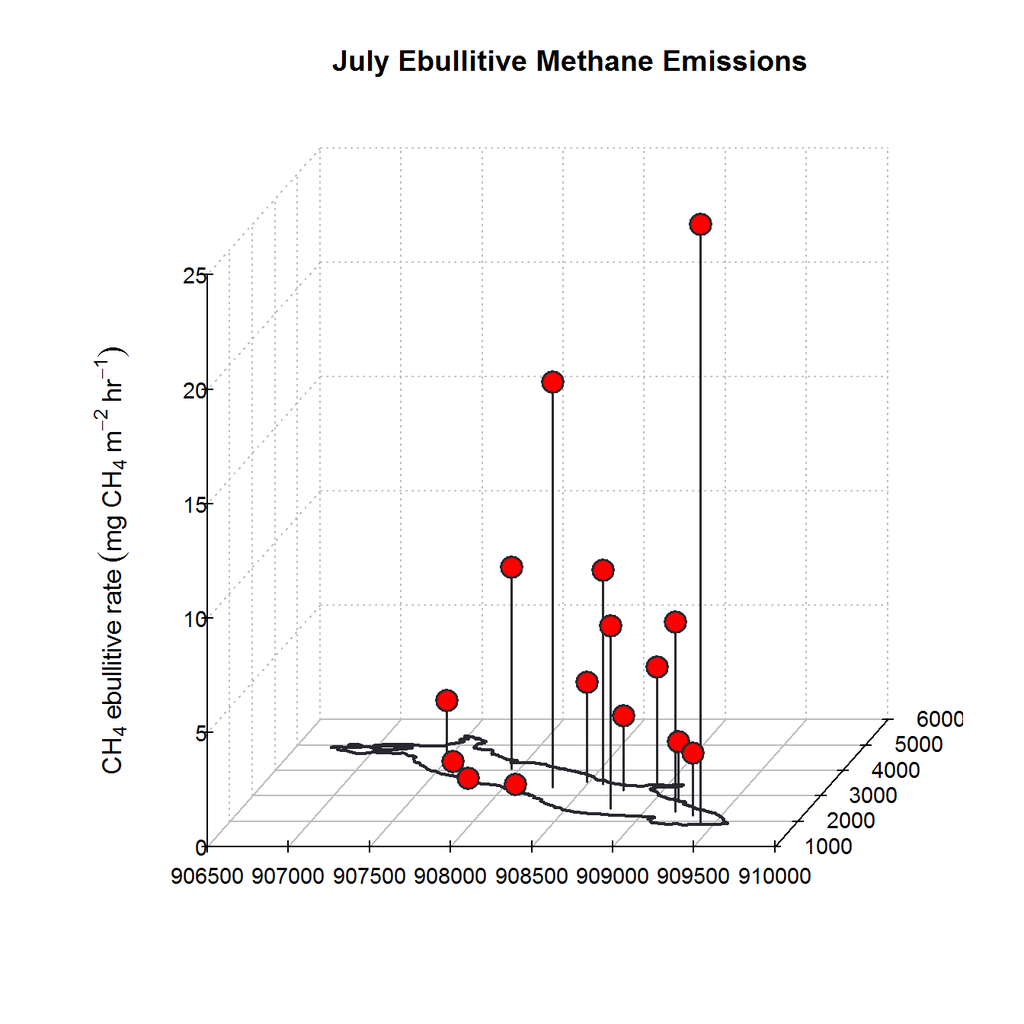

*Methane ebullitive emissions from July 10<sup>th</sup> - 11<sup>th</sup> measured at the 15 sample sites within Acton Lake. The height of each “lollipop” corresponds to the emission rate shown on the vertical z-axis in units of milligrams CH<sub>4</sub> per square meter of lake surface per hour. The x- and y-axes are oriented east-west and north-south, respectively.*

July 10<sup>th</sup> diffusive methane emissions

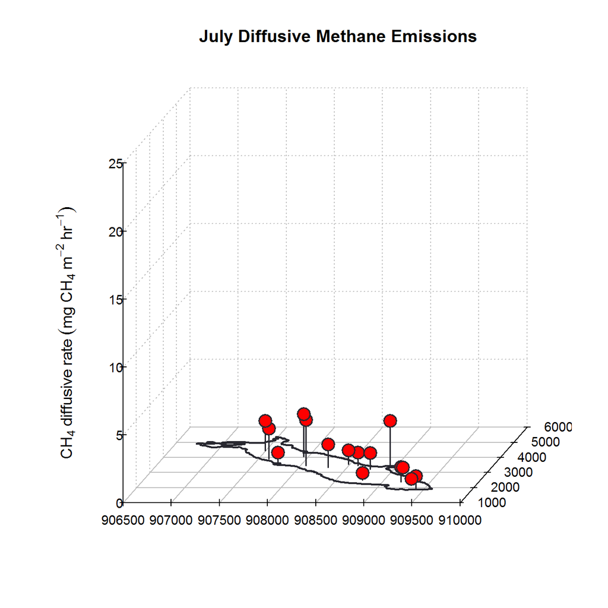

*Methane diffusive emissions from July 10<sup>th</sup> - 11<sup>th</sup> measured at the 15 sample sites within Acton Lake.*

August 31<sup>st</sup> ebullitive methane emissions

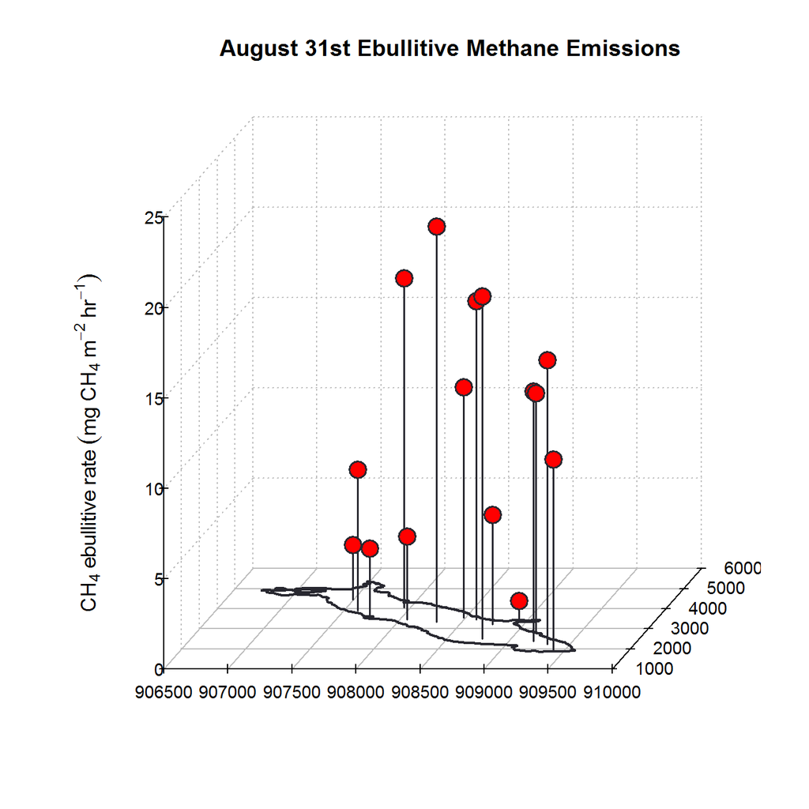

*Methane ebullitive emissions from August 31<sup>st</sup> - Sept 1<sup>st</sup> measured at the 15 sample sites within Acton Lake.*

August 31<sup>st</sup> diffusive methane emissions

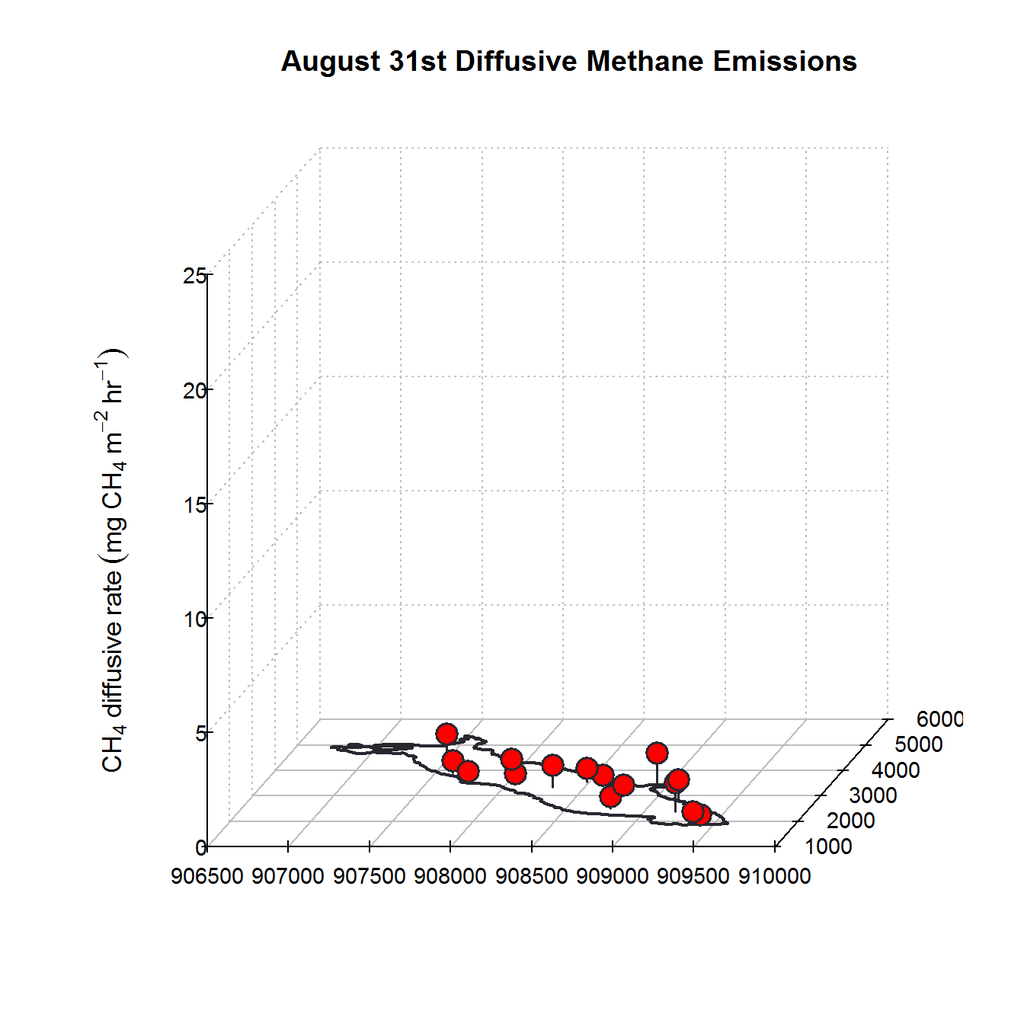

*Methane diffusive emissions from August 31<sup>st</sup> - Sept 1<sup>st</sup> measured at the 15 sample sites within Acton Lake.*

October 4<sup>th</sup> volumetric gas emissions

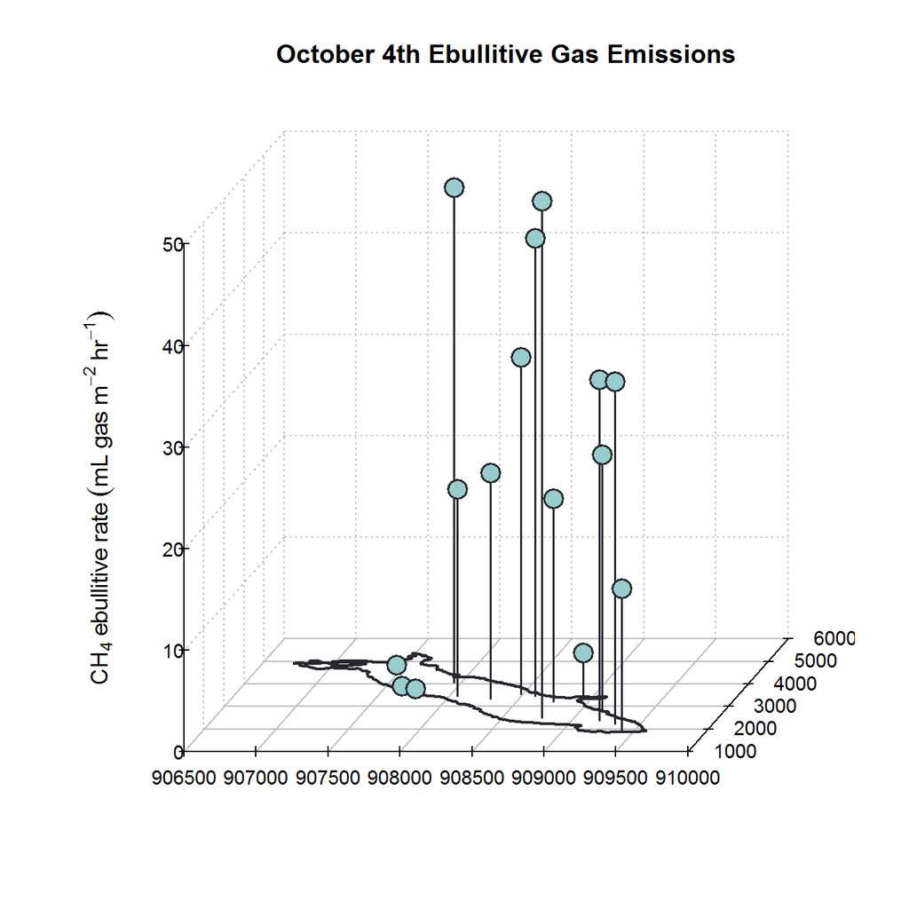

*Gas ebullitive emissions from October 4<sup>th</sup> - 5<sup>th</sup> measured at the 15 sample sites within Acton Lake.*

October 4<sup>th</sup> diffusive methane emissions

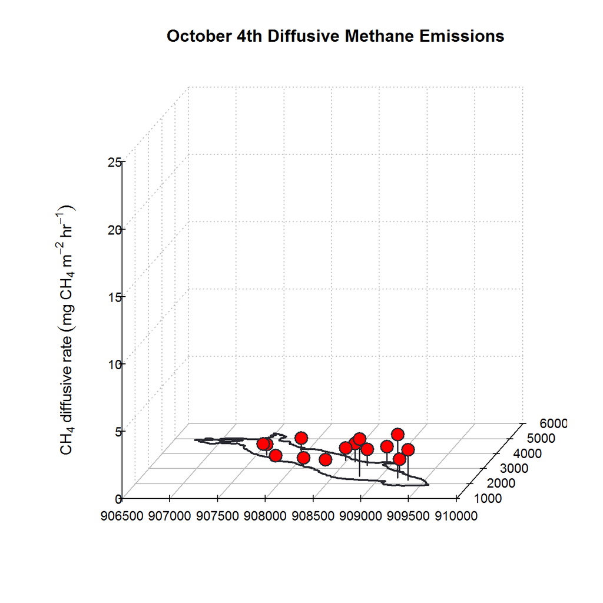

*Methane diffusive emissions from October 4<sup>th</sup> - 5<sup>th</sup> measured at the 15 sample sites within Acton Lake.*

July 10<sup>th</sup> ebullitive CO<sub>2</sub> emissions

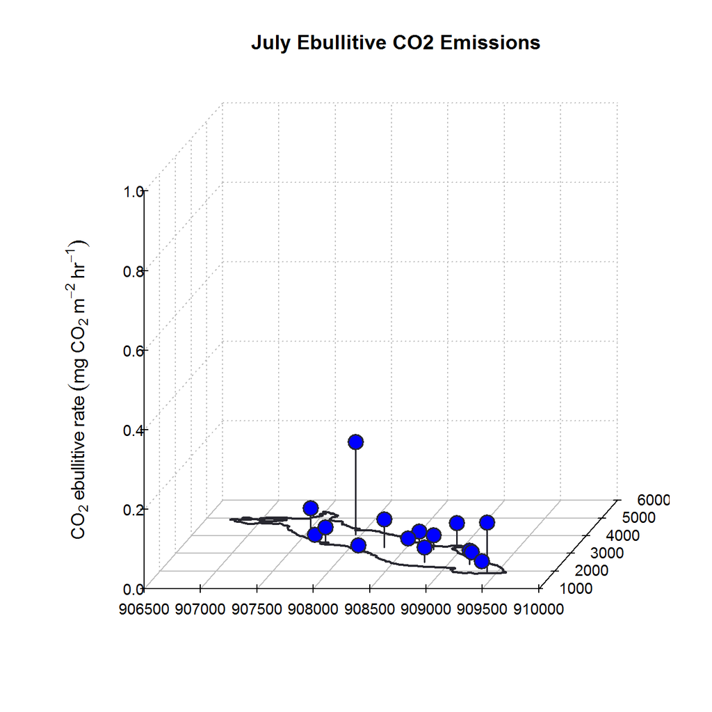

July 10<sup>th</sup> diffusive CO<sub>2</sub> uptake

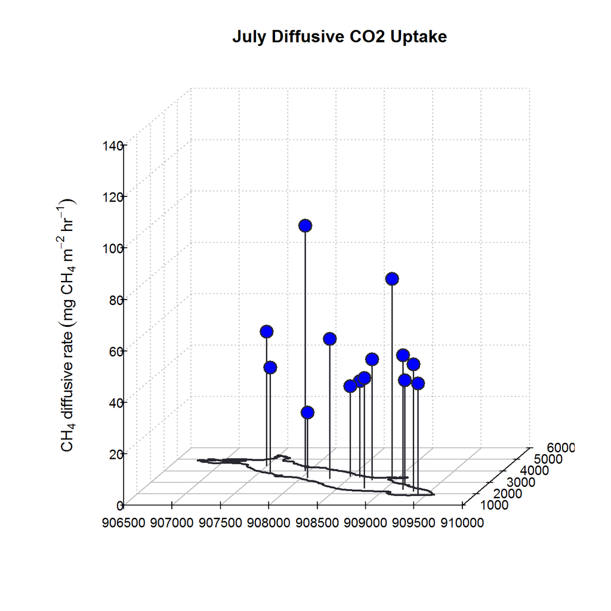

*Carbon dioxide diffusive uptake from July 10<sup>th</sup> - 11<sup>th</sup> measured at the 15 sample sites within Acton Lake.*

August 31<sup>st</sup> ebullitive CO<sub>2</sub> emissions

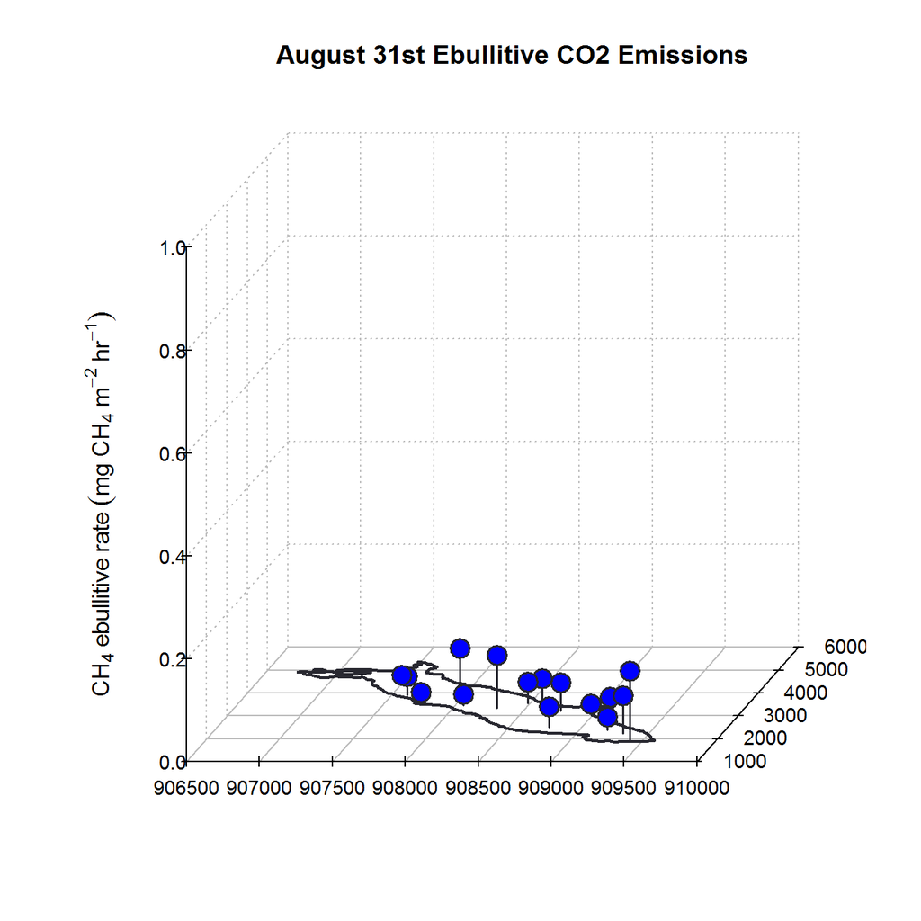

*Carbon dioxide ebullitive emissions from August 31<sup>st</sup> - Sept 1<sup>st</sup> measured at the 15 sample sites within Acton Lake.*

August 31<sup>st</sup> diffusive CO<sub>2</sub> uptake

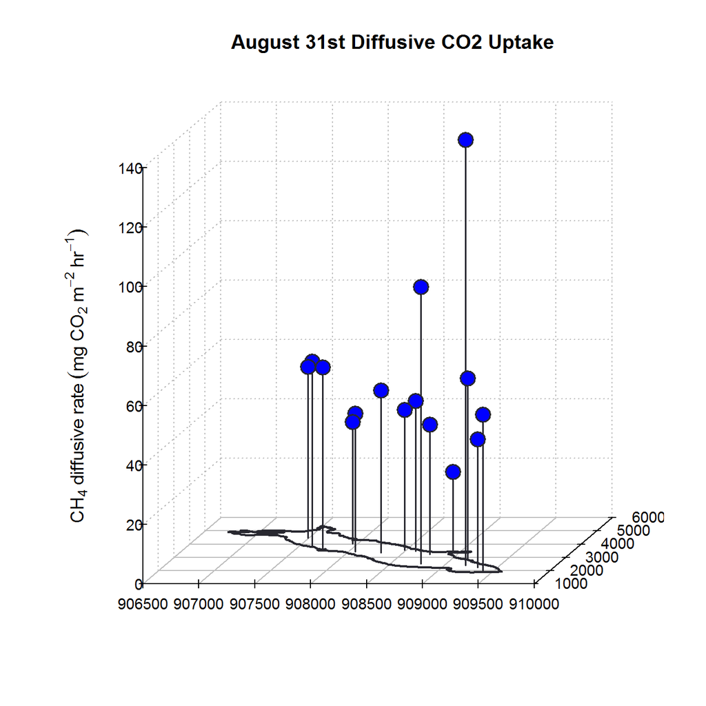

*Carbon dioxide diffusive emissions from August 31<sup>st</sup> - Sept 1<sup>st</sup> measured at the 15 sample sites within Acton Lake.*

October 4<sup>th</sup> volumetric gas emissions

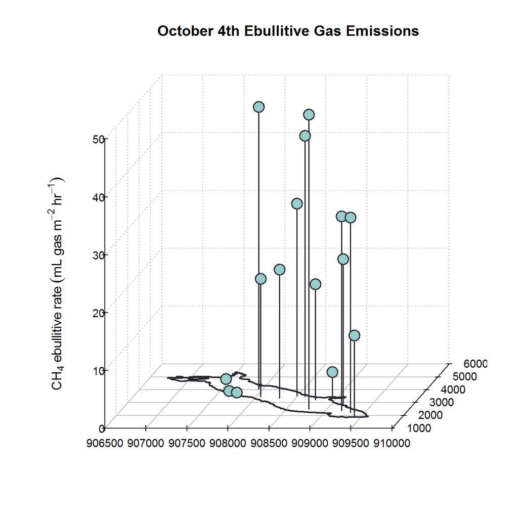

*Gas ebullitive emissions from October 4<sup>th</sup> - 5<sup>th</sup> measured at the 15 sample sites within Acton Lake.*

October 4<sup>th</sup> diffusive CO<sub>2</sub> uptake

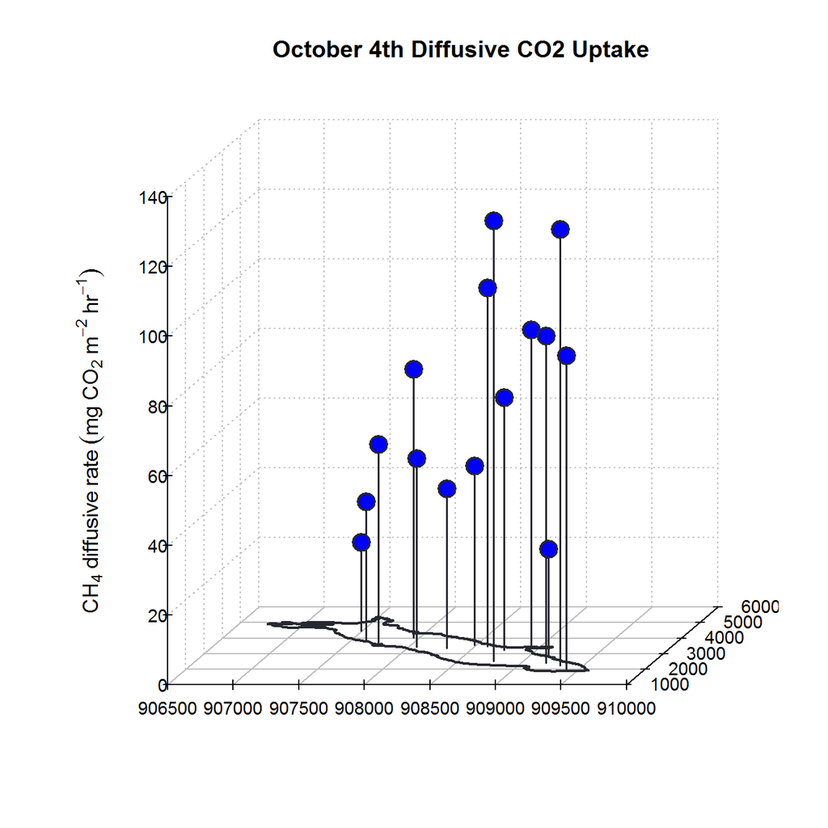

*Carbon dioxide diffusive emissions from October 4<sup>th</sup> - 5<sup>th</sup> measured at the 15 sample sites within Acton Lake.*

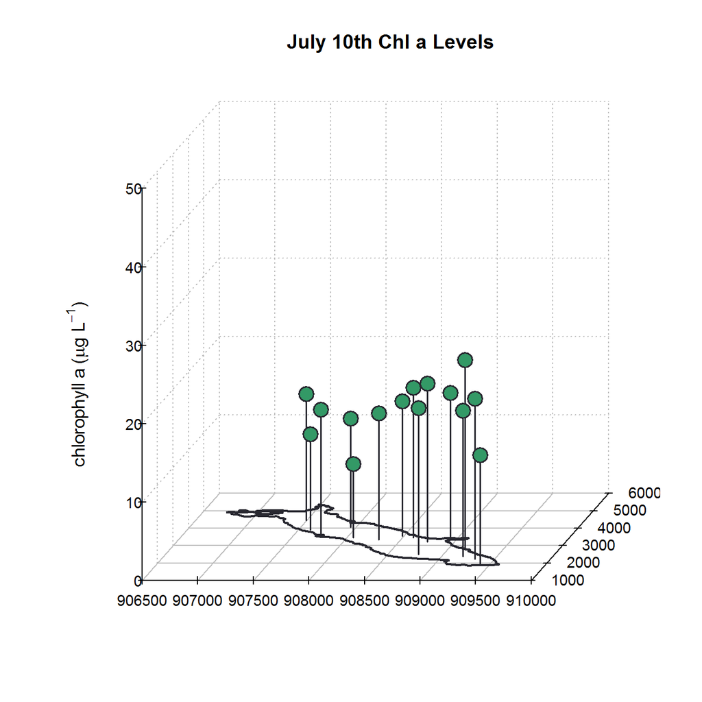

*Chlorophyll a concentrations measured at the 15 sample sites within Acton Lake in July. The height of each “lollipop” corresponds to the concentration shown on the vertical z-axis in units of micrograms per liter of water. The x- and y-axes are oriented east-west and north-south, respectively.*

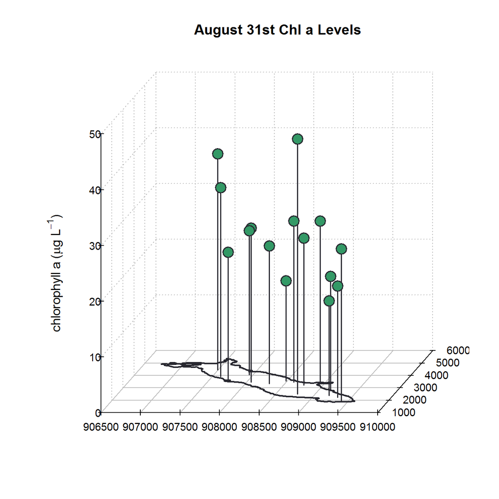

*Chlorophyll a concentrations measured at the 15 sample sites within Acton Lake in August. The height of each “lollipop” corresponds to the concentration shown on the vertical z-axis in units of micrograms per liter of water. The x- and y-axes are oriented east-west and north-south, respectively.*

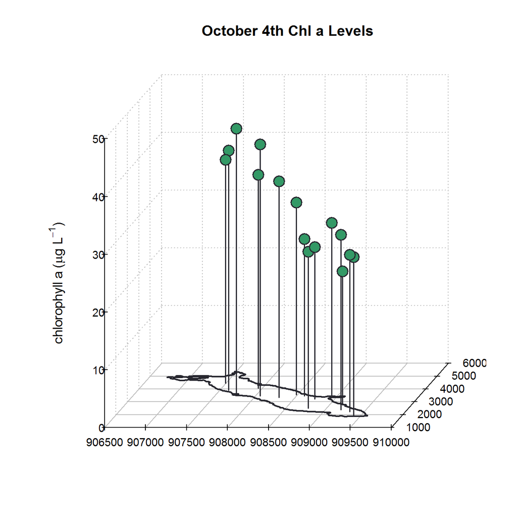

*Chlorophyll a concentrations measured at the 15 sample sites within Acton Lake in October. The height of each “lollipop” corresponds to the concentration shown on the vertical z-axis in units of micrograms per liter of water. The x- and y-axes are oriented east-west and north-south, respectively.*

## 5. Tables of measured values at each site

Table 1: Surface (0.1 m) water quality parameters measured via sonde at each site on July 10<sup>th</sup>

| Site ID | Latitude | Longitude | Chl a (ug/L) | DO (mg/L) | pH | Sp. Cond | Water Temp (C) | Turbidity |
| --- | --- | --- | --- | --- | --- | --- | --- | --- |
| U-01 | 39.57155 | 84.74441 | 19.1 | 11.9 | 8.8 | 377 | 25.0 | 23.1 |
| U-04 | NA | NA | 13.9 | 11.7 | 8.8 | 378 | 24.7 | 20.6 |
| U-05 | 39.57193 | 84.75092 | 9.4 | 12.0 | 8.7 | 409 | 26.1 | 29.5 |
| U-06 | 39.57630 | 84.75570 | 12.2 | 11.9 | 8.6 | 387 | 24.5 | 53.1 |
| U-07 | 39.57020 | 84.74001 | 18.7 | 12.5 | 8.8 | 378 | 25.4 | 36.3 |
| U-08 | 39.56173 | 84.73852 | 18.6 | 15.1 | 8.8 | 370 | 26.1 | 15.7 |
| U-09 | 39.57383 | 84.75453 | 15.9 | 11.5 | 8.8 | 395 | 23.9 | 54.9 |
| U-11 | 39.56507 | 84.73036 | 24.2 | 15.0 | 8.9 | 370 | 26.1 | 15.9 |
| U-12 | 39.56030 | 84.73719 | 20.5 | 14.1 | 8.9 | 372 | 25.5 | 17.6 |
| U-13 | 39.57232 | 84.74557 | 17.2 | 12.3 | 8.8 | 378 | 25.3 | 19.5 |
| U-14 | 39.58084 | 84.75620 | 16.1 | 12.4 | 8.4 | 389 | 24.6 | 43.7 |
| U-15 | 39.56328 | 84.74365 | 18.7 | 14.0 | 8.8 | 375 | 25.6 | 15.9 |
| U-16 | 39.57067 | 84.74804 | 16.1 | 12.3 | 8.8 | 388 | 25.2 | 21.3 |
| U-17 | 39.57708 | 84.75137 | 13.9 | 12.1 | 8.6 | 390 | 24.9 | 19.0 |
| U-18 | 39.56912 | 84.74257 | 20.2 | 12.4 | 8.8 | 370 | 24.9 | 20.6 |

Table 2: Surface (0.1 m) water quality parameters measured via sonde at each site on August 31<sup>st</sup>

| Site ID | Latitude | Longitude | Chl a (ug/L) | DO (mg/L) | pH | Sp. Cond | Water Temp (C) | Turbidity |
| --- | --- | --- | --- | --- | --- | --- | --- | --- |
| U-01 | 39.57155 | 84.74441 | 28.9 | 14.8 | 9.1 | 312 | 25.6 | 10.0 |
| U-04 | NA | NA | 27.3 | 19.1 | 9.3 | 303 | 26.9 | 11.7 |
| U-05 | 39.57193 | 84.75092 | 27.7 | 14.2 | 9.1 | 310 | 25.3 | 9.7 |
| U-06 | 39.57630 | 84.75570 | 33.9 | 13.2 | 9.0 | 313 | 24.8 | 13.6 |
| U-07 | 39.57020 | 84.74001 | 29.1 | 11.5 | 8.9 | 319 | 25.2 | 21.1 |
| U-08 | 39.56173 | 84.73852 | 17.0 | 18.6 | 9.3 | 304 | 27.1 | 10.6 |
| U-09 | 39.57383 | 84.75453 | 22.9 | 12.9 | 9.0 | 314 | 25.3 | 12.5 |
| U-11 | 39.56507 | 84.73036 | 20.5 | 12.7 | 9.0 | 316 | 26.4 | 8.1 |
| U-12 | 39.56030 | 84.73719 | 20.0 | 18.0 | 9.3 | 305 | 27.0 | 10.4 |
| U-13 | 39.57232 | 84.74557 | 18.0 | 12.8 | 9.0 | 316 | 25.4 | 8.8 |
| U-14 | 39.58084 | 84.75620 | 38.8 | 12.3 | 8.8 | 310 | 24.1 | 23.5 |
| U-15 | 39.56328 | 84.74365 | 45.8 | 20.9 | 9.4 | 298 | 27.0 | 13.3 |
| U-16 | 39.57067 | 84.74804 | 24.7 | 15.2 | 9.1 | 309 | 25.6 | 9.7 |
| U-17 | 39.57708 | 84.75137 | 25.9 | 13.9 | 9.0 | 312 | 25.1 | 9.9 |
| U-18 | 39.56912 | 84.74257 | 26.4 | 10.4 | 8.8 | 319 | 26.1 | 8.8 |

Table 3: Surface (0.1 m) water quality parameters measured via sonde at each site on October 4<sup>th</sup>

| Site ID | Latitude | Longitude | Chl a (ug/L) | DO (mg/L) | pH | Sp. Cond | Water Temp (C) | Turbidity |
| --- | --- | --- | --- | --- | --- | --- | --- | --- |
| U-01 | 39.57155 | 84.74441 | 27.2 | 11.8 | 8.9 | 0 | 21.6 | 7.2 |
| U-04 | NA | NA | 27.4 | 12.5 | 9.0 | 0 | 21.8 | 7.3 |
| U-05 | 39.57193 | 84.75092 | 43.6 | 11.4 | 8.9 | 0 | 21.8 | 17.2 |
| U-06 | 39.57630 | 84.75570 | 41.5 | 10.9 | 8.9 | 0 | 21.7 | 23.0 |
| U-07 | 39.57020 | 84.74001 | 30.2 | 12.2 | 8.9 | 0 | 22.0 | 7.8 |
| U-08 | 39.56173 | 84.73852 | 30.3 | 10.9 | 8.9 | 0 | 21.5 | 8.0 |
| U-09 | 39.57383 | 84.75453 | 45.9 | 11.6 | 8.9 | 0 | 21.8 | 18.4 |
| U-11 | 39.56507 | 84.73036 | 23.1 | 12.6 | 9.0 | 0 | 21.9 | 7.7 |
| U-12 | 39.56030 | 84.73719 | 27.2 | 11.2 | 8.9 | 0 | 21.6 | 8.7 |
| U-13 | 39.57232 | 84.74557 | 33.3 | 11.8 | 8.9 | 0 | 21.5 | 8.6 |
| U-14 | 39.58084 | 84.75620 | 38.7 | 10.1 | 8.8 | 0 | 21.8 | 18.2 |
| U-15 | 39.56328 | 84.74365 | 27.1 | 12.5 | 9.0 | 0 | 21.8 | 9.3 |
| U-16 | 39.57067 | 84.74804 | 37.4 | 10.5 | 8.8 | 0 | 21.2 | 9.1 |
| U-17 | 39.57708 | 84.75137 | 37.0 | 11.2 | 8.8 | 0 | 21.6 | 11.0 |
| U-18 | 39.56912 | 84.74257 | 26.3 | 11.7 | 8.9 | 0 | 21.6 | 6.4 |

## 6. EPA disclaimer

The U.S. Environmental Protection Agency, through its Office of Research and Development, participated in the research described herein. It has been subjected to the Agency’s administrative review and has been approved for limited external distribution. Any opinions expressed in this article are those of the authors and do not necessarily reflect the views of the Agency, therefore, no official endorsement should be inferred. Any mention of trade names or commercial products does not constitute endorsement or recommendation for use.